# Practical Machine Learning Course Project

Jamin Wong

2022-07-11

# Abstract

The goal of the project is to predict the manner in which the subject did the exercise. The variable “classe” is the variable to be predicted.

## Weight Lifting Dataset

Six young health participants were asked to perform one set of 10 repetitions of the Unilateral Dumbbell Biceps Curl in five different fashions: exactly according to the specification (Class A), throwing the elbows to the front (Class B), lifting the dumbbell only halfway (Class C), lowering the dumbbell only halfway (Class D) and throwing the hips to the front (Class E).

## Load data

```r
trainingset <- read.csv("https://d396qusza40orc.cloudfront.net/predmachlearn/pml-training.csv",
    na.strings = c("NA", ""))

testing <- read.csv("https://d396qusza40orc.cloudfront.net/predmachlearn/pml-testing.csv",
    na.strings = c("NA", ""))
```

# Exploratory Analysis

## Frequency of classes

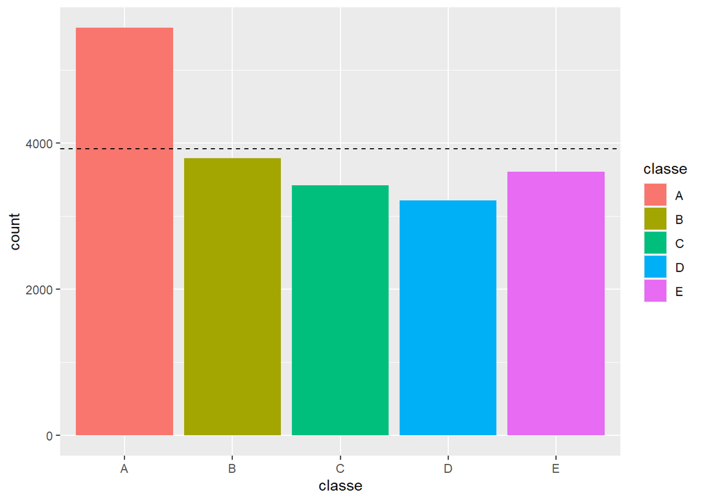

```r
g <- ggplot(trainingset, aes(x = classe, fill = classe))
g + geom_bar() + geom_hline(yintercept = dim(trainingset)[1]/5,
    linetype = "dashed")
```

Class A (exactly according to the specification) has the highest frequency while class D (lowering the dumbbell only halfway) has the lowest frequency.  
Only class A is above the mean count.

## Read the training set

```r
str(trainingset)
```

```
## 'data.frame':    19622 obs. of  160 variables:
##  $ X                       : int  1 2 3 4 5 6 7 8 9 10 ...
##  $ user_name               : chr  "carlitos" "carlitos" "carlitos" "carlitos" ...
##  $ raw_timestamp_part_1    : int  1323084231 1323084231 1323084231 1323084232 1323084232 1323084232 1323084232 1323084232 1323084232 1323084232 ...
##  $ raw_timestamp_part_2    : int  788290 808298 820366 120339 196328 304277 368296 440390 484323 484434 ...
##  $ cvtd_timestamp          : chr  "05/12/2011 11:23" "05/12/2011 11:23" "05/12/2011 11:23" "05/12/2011 11:23" ...
##  $ new_window              : chr  "no" "no" "no" "no" ...
##  $ num_window              : int  11 11 11 12 12 12 12 12 12 12 ...
##  $ roll_belt               : num  1.41 1.41 1.42 1.48 1.48 1.45 1.42 1.42 1.43 1.45 ...
##  $ pitch_belt              : num  8.07 8.07 8.07 8.05 8.07 8.06 8.09 8.13 8.16 8.17 ...
##  $ yaw_belt                : num  -94.4 -94.4 -94.4 -94.4 -94.4 -94.4 -94.4 -94.4 -94.4 -94.4 ...
##  $ total_accel_belt        : int  3 3 3 3 3 3 3 3 3 3 ...
##  $ kurtosis_roll_belt      : chr  NA NA NA NA ...
##  $ kurtosis_picth_belt     : chr  NA NA NA NA ...
##  $ kurtosis_yaw_belt       : chr  NA NA NA NA ...
```

[output cut: 86 more lines]

# Clean data

## Remove column with na

```r
trainingset <- trainingset %>%
    select_if(~!any(is.na(.)))
testing <- testing %>%
    select_if(~!any(is.na(.)))
```

## Remove timesstamp and index

```r
toBeRemove <- grep("timestamp|^X|user_name|new_window", names(trainingset))
trainingset <- trainingset[, -toBeRemove]
testing <- testing[, -toBeRemove]
trainingset <- mutate_if(trainingset, is.character, as.factor)
testing <- mutate_if(testing, is.character, as.factor)
```

## Create cross validation set

```r
set.seed(1234)
inTrain <- createDataPartition(trainingset$classe, p = 0.8, list = FALSE)
training <- trainingset[inTrain, ]
cvd <- trainingset[-inTrain, ]
```

# Model Training

## Decision Tree

```r
dtmod <- rpart(classe ~ ., data = training, method = "class")

resultdt <- predict(dtmod, newdata = cvd, type = "class")

dtmat <- confusionMatrix(resultdt, cvd$classe)
```

### Confusion Matrix (Decision Tree)

```r
dtmat
```

```
## Confusion Matrix and Statistics
##
##           Reference
## Prediction    A    B    C    D    E
##          A 1013  137   26   49   46
##          B   37  448   27   51   74
##          C    4   43  543   87   59
##          D   53   80   48  428   88
##          E    9   51   40   28  454
##
## Overall Statistics
##
##                Accuracy : 0.7357
##                  95% CI : (0.7216, 0.7494)
##     No Information Rate : 0.2845
##     P-Value [Acc > NIR] : < 2.2e-16
##
##                   Kappa : 0.6643
##
##  Mcnemar's Test P-Value : < 2.2e-16
##
## Statistics by Class:
##
##                      Class: A Class: B Class: C Class: D Class: E
## Sensitivity            0.9077   0.5903   0.7939   0.6656   0.6297
## Specificity            0.9081   0.9403   0.9404   0.9180   0.9600
## Pos Pred Value         0.7970   0.7033   0.7378   0.6141   0.7801
## Neg Pred Value         0.9612   0.9054   0.9558   0.9334   0.9201
## Prevalence             0.2845   0.1935   0.1744   0.1639   0.1838
## Detection Rate         0.2582   0.1142   0.1384   0.1091   0.1157
## Detection Prevalence   0.3240   0.1624   0.1876   0.1777   0.1484
## Balanced Accuracy      0.9079   0.7653   0.8671   0.7918   0.7949
```

## Random Forest

```r
rfmod <- train(classe ~ ., method = "rf", data = training, trControl = trainControl(method = "cv",
    number = 3), metric = "Accuracy")

resultrf <- predict(rfmod, newdata = cvd)

rfmat <- confusionMatrix(resultrf, cvd$classe)
```

### Confusion Matrix (Random Forest)

```r
rfmat
```

```
## Confusion Matrix and Statistics
##
##           Reference
## Prediction    A    B    C    D    E
##          A 1116    2    0    0    0
##          B    0  756    1    0    0
##          C    0    1  683    5    0
##          D    0    0    0  638    2
##          E    0    0    0    0  719
##
## Overall Statistics
##
##                Accuracy : 0.9972
##                  95% CI : (0.995, 0.9986)
##     No Information Rate : 0.2845
##     P-Value [Acc > NIR] : < 2.2e-16
##
##                   Kappa : 0.9965
##
##  Mcnemar's Test P-Value : NA
##
## Statistics by Class:
##
##                      Class: A Class: B Class: C Class: D Class: E
## Sensitivity            1.0000   0.9960   0.9985   0.9922   0.9972
## Specificity            0.9993   0.9997   0.9981   0.9994   1.0000
## Pos Pred Value         0.9982   0.9987   0.9913   0.9969   1.0000
## Neg Pred Value         1.0000   0.9991   0.9997   0.9985   0.9994
## Prevalence             0.2845   0.1935   0.1744   0.1639   0.1838
## Detection Rate         0.2845   0.1927   0.1741   0.1626   0.1833
## Detection Prevalence   0.2850   0.1930   0.1756   0.1631   0.1833
## Balanced Accuracy      0.9996   0.9979   0.9983   0.9958   0.9986
```

# Result

The Random Forest model has a higher accuracy of 0.997196 than that of decision tree of 0.7356615.  
Hence, the random forest model will be used.

## Out of sample error

The out of sample error will be 0.002804.

## Prediction of the testing set

```r
result <- predict(rfmod, newdata = testing)

result
```

```
##  [1] B A B A A E D B A A B C B A E E A B B B
## Levels: A B C D E
```